# Introduction

This task aims at developing a model that can accurately predict the relevance of search results for HomeDepot. The key element for analyzing relevance is to evaluate the similarity between search term and product details (including product title, product description and product attributes). To evaluate this similarity, we implemented two iterations of feature engineering methods.

The first iteration (baseline) is to find the number of common words and the fuzzy similarity score between search terms and product details. For the first iteration, we ran two models: linear regression and random forest. The result showed that though random forest model outperformed linear regression, its result (around 0.49) is still comparatively high.

To improve the performance, we further incorporated word2vec cosine similarity score in the second iteration of feature engineering. The results of second iteration clearly outperform the first iteration. And with parameter tuning, we reached a RMSE score of 0.474 on Kaggle test data set using the random forest model.

# Iteration 1 - Baseline (Common count and fuzzy score)

In this baseline iteration, we use two methods to evaluate the similarity between search term and product details. The first method is to find the number of common words occur in both search terms and product details. The second method is to find the fuzzy score between search terms and product details. Fuzzy score is a means of evaluating the proximity between strings. The general idea is to have a given string: s1 and a target string: s2; try to find approximate substrings in s2 that matches the patterns of s1 and evaluate their similarity using a fuzzy score.

## Data loading and pre-processing

First, we load the data from four csv files, and combine the product_description data with the train and test data seperately based on the product_uid.

```python
import numpy as np
import pandas as pd
from nltk.stem import WordNetLemmatizer
from nltk.corpus import stopwords
```

```python
# load data
test_data = pd.read_csv("test.csv",encoding="ISO-8859-1")
train_data = pd.read_csv('train.csv', encoding="ISO-8859-1")
attributes = pd.read_csv("attributes.csv", encoding="ISO-8859-1")
product_description = pd.read_csv("product_descriptions.csv",encoding="ISO-8859-1")
# merge product_description file
train = pd.merge(train_data, product_description, how='left', on='product_uid')
test = pd.merge(test_data, product_description, how='left', on='product_uid')
```

Then, we remove the punctuations in search term, product title and product descriptions. We only keep alphanumeric characters and whitespaces in "search_term", "product_title" and "product_description". This is because in HomeDepot searches and product details, there can be inconsistency in the use of punctuations, we remove this factor to increase the accuracy of our model.

```python
train["search_term"] = train["search_term"].str.replace("[^\w\s]","")
train["product_title"] = train["product_title"].str.replace("[^\w\s]","")
train["product_description"] = train["product_description"].str.replace("[^\w\s]","")
test["search_term"] = test["search_term"].str.replace("[^\w\s]","")
test["product_title"] = test["product_title"].str.replace("[^\w\s]","")
test["product_description"] = test["product_description"].str.replace("[^\w\s]","")
```

We further process the words using the following two methods: lemmatization and remove stop words. Since there can be inconsistency in the use of singular or plural forms of words, we perform lemmatization to ensure all words are in singular and original format. Removing stop words will further increase the accuracy of our model, since stop words don't have specific meanings and may inflate our similarity score if included.

```python
def process_word(s):
    lemmatizer = WordNetLemmatizer()
    lemmatize_result_str = ""
    for word in s.lower().split():
        if len(lemmatize_result_str) == 0:
            lemmatize_result_str = lemmatizer.lemmatize(word)
        else:
            lemmatize_result_str = lemmatize_result_str + " " + lemmatizer.lemmatize(word)
    stop_words = set(stopwords.words('english'))
    result_str = ""
    for word in lemmatize_result_str.split():
        if word not in stop_words:
            if len(result_str) == 0:
                result_str = word
            else:
                result_str = result_str + " " + word
    return result_str
```

Finally, we apply the function above to the content of "search_term", "product_title" and "product_description" attributes of training and test data to lemmatize words and remove stop_words.

```python
train["search_term"] = train["search_term"].map(lambda x:process_word(x))
train["product_title"] = train["product_title"].map(lambda x:process_word(x))
train["product_description"] = train["product_description"].map(lambda x:process_word(x))
test["search_term"] = test["search_term"].map(lambda x:process_word(x))
test["product_title"] = test["product_title"].map(lambda x:process_word(x))
test["product_description"] = test["product_description"].map(lambda x:process_word(x))
```

## Feature engineering for product title and description

First, we start from getting the length of search query. This can be an important feature since longer search query may reflect more accurate searches and hence, have higher relevance score.

```python
# length of search query
train['search_query_length'] = train['search_term'].map(lambda x:len(x.split())).astype(np.int64)
test['search_query_length'] = test['search_term'].map(lambda x:len(x.split())).astype(np.int64)
```

Then, we write the common function to find the number of each word in search term occur in product title and descriptions. This is also an important feature, the more frequent the search term occurs, the higher the relevance score is.

```python
# Common function
def common(s1, s2):
    return sum(int(s2.find(word)>=0) for word in s1.split())
```

```python
# calculate number of common words in product title and description
train['search_title_des'] = train['search_term']+"\t"+train['product_title']+"\t"+train['product_description']
test['search_title_des'] = test['search_term']+"\t"+test['product_title']+"\t"+test['product_description']
train['common_count_title'] = train['search_title_des'].map(lambda x:common(x.split('\t')[0],x.split('\t')[1]))
train['common_count_description'] = train['search_title_des'].map(lambda x:common(x.split('\t')[0],x.split('\t')[2]))
test['common_count_title'] = test['search_title_des'].map(lambda x:common(x.split('\t')[0],x.split('\t')[1]))
test['common_count_description'] = test['search_title_des'].map(lambda x:common(x.split('\t')[0],x.split('\t')[2]))
```

Finally, we get the fuzzy score between search term and product title/description. A higher fuzzy score reflects a higher similarity between two strings and the fuzzy score ranges from 0 to 100, with 100 meaning higher similarity.

```python
# get fuzzy score between search words and product title/description
from fuzzywuzzy import fuzz
train['fuzz_title'] = train['search_title_des'].map(lambda x:fuzz.token_set_ratio(x.split('\t')[0],x.split('\t')[1]))
train['fuzz_des'] = train['search_title_des'].map(lambda x:fuzz.token_set_ratio(x.split('\t')[0],x.split('\t')[2]))
test['fuzz_title'] = test['search_title_des'].map(lambda x:fuzz.token_set_ratio(x.split('\t')[0],x.split('\t')[1]))
test['fuzz_des'] = test['search_title_des'].map(lambda x:fuzz.token_set_ratio(x.split('\t')[0],x.split('\t')[2]))
```

## Feature engineering for product attributes

Here, we perform the similar feature engineering to product attributes. We first start from merging all product attributes to the train and test dataframe.

```python
# merge name and value in attributes
def merge(attr):
    names = attr["name"]
    values = attr["value"]
    merge = []
    for name, value in zip(names, values):
        merge.append(" ".join((name, value)))
    return " ".join(merge)
```

```python
# merge product attributes with train and test file
attributes.dropna(how="all", inplace=True)
attributes["product_uid"] = attributes["product_uid"].astype(int)
attributes["value"] = attributes["value"].astype(str)
product_attributes = attributes.groupby("product_uid").apply(merge)
product_attributes = product_attributes.reset_index(name="product_attributes")
train = pd.merge(train, product_attributes, how="left", on="product_uid")
test = pd.merge(test, product_attributes, how="left", on="product_uid")
```

We perform the same word process and remove punctuation steps on the product attributes. Also, we get the common count and fuzzy score between product attributes and search terms. This concludes our feature engineering steps for iteration 1 and we export the features to csv file.

```python
train["product_attributes"] = train["product_attributes"].str.replace("[^\w\s]","")
test["product_attributes"] = test["product_attributes"].str.replace("[^\w\s]","")
```

```python
def replace_nan(s):
        if pd.isnull(s)==True:
                s=""
        return s
```

```python
train['product_attributes'] = train['product_attributes'].map(lambda x:replace_nan(x))
train['product_attributes'] = train['product_attributes'].map(lambda x:process_word(x))
train['search_attri'] = train['search_term'] + "\t" + train['product_attributes']
train['common_count_attri'] = train['search_attri'].map(lambda x:common(x.split('\t')[0],x.split('\t')[1]))
train['fuzz_attri'] = train['search_attri'].map(lambda x:fuzz.token_set_ratio(x.split('\t')[0],x.split('\t')[1]))
```

```python
test['product_attributes'] = test['product_attributes'].map(lambda x:replace_nan(x))
test['product_attributes'] = test['product_attributes'].map(lambda x:process_word(x))
test['search_attri'] = test['search_term'] + "\t" + test['product_attributes']
test['common_count_attri'] = test['search_attri'].map(lambda x:common(x.split('\t')[0],x.split('\t')[1]))
test['fuzz_attri'] = test['search_attri'].map(lambda x:fuzz.token_set_ratio(x.split('\t')[0],x.split('\t')[1]))
```

```python
train.to_csv('train_iteration_1.csv')
```

```python
test.to_csv('test_iteration_1.csv')
```

## Predicting relevance

### Preparing for Spark

We used Apache pyspark package to perform batch data processing with built-in machine learning models. We first imported test and training data with features from the previous step into pyspark dataframe. Then we splited the training data into training set and validation set to better validate the model's performance. Next, we transformed training data using the features we extracted, which are 'search_query_length','common_count_title', 'common_count_description','fuzz_title','fuzz_des'.

```python
from pyspark.mllib.tree import RandomForest, RandomForestModel
from pyspark.mllib.util import MLUtils
from pyspark import SparkContext
from pyspark.sql import SparkSession
# create SparkContext if sc doesn't exist.
try:
    sc
except NameError:
    sc =SparkContext()
from pyspark.sql import SparkSession
from pyspark.ml.feature import IndexToString, StringIndexer
from pyspark.ml import Pipeline
from pyspark.ml.classification import RandomForestClassifier
from pyspark.ml.feature import IndexToString, StringIndexer, VectorIndexer
from pyspark.ml.evaluation import MulticlassClassificationEvaluator
from pyspark.ml.linalg import Vectors
from pyspark.ml.feature import VectorAssembler
from pyspark.ml.regression import RandomForestRegressor
from pyspark.ml.feature import VectorIndexer
from pyspark.ml.evaluation import RegressionEvaluator
import os
from pyspark.sql.types import IntegerType
from pyspark.sql.types import FloatType
from pyspark.ml.regression import LinearRegression
from pyspark.mllib.linalg import SparseVector
from pyspark.sql.functions import udf
from pyspark.ml.evaluation import RegressionEvaluator
```

```python
spark = SparkSession.builder.appName("FinalPrj").getOrCreate()
df_train = spark.read.csv("train_iteration_1.csv", header=True, inferSchema=True)
(trainingData, validData) = df_train.randomSplit([0.7, 0.3])
vs = VectorAssembler(inputCols=['search_query_length','common_count_title',
                                'common_count_description','fuzz_title','fuzz_des'], outputCol='features')
train = vs.transform(trainingData)
valid = vs.transform(validData)
```

```python
df_test = spark.read.csv("test_iteration_1.csv", header=True, inferSchema=True)
test = vs.transform(df_test)
```

### Machine Learning Model Implementation

After we successfully imported the training and test data, we tried two built-in machine learning models to predict the revelance, which are linear regression and random forest. We picked linear regression model because it is a classic approach for supervised learning and it is easy to understand. We also picked random forest model because of two major reasons:

- Reduction in overfitting
  - by averaging several trees, there is a significantly lower risk of overfitting.
- Less variance:
  - By using multiple trees, we can reduce the chance of stumbling across a classifier that doesn’t perform well because of the relationship between the train and test data.

### Linear Regression Model

We first train the linear regression model on the train and cross validation dataset. The cross validation returns a RMSE of 0.489.

```python
lr = LinearRegression(featuresCol='features', labelCol='relevance', maxIter=1000)
model_lr = lr.fit(train)
lr_summary = model_lr.summary
print("RMSE: %f" % lr_summary.rootMeanSquaredError)
```

```
RMSE: 0.491789
```

```python
valid_lr = model_lr.transform(valid)
evaluator = RegressionEvaluator(labelCol="relevance", predictionCol="prediction", metricName="rmse")
rmse = evaluator.evaluate(valid_lr)
print("Root Mean Squared Error (RMSE) on validation data = %g" % rmse)
```

```
Root Mean Squared Error (RMSE) on validation data = 0.489385
```

### Random Forest Model

We then train the random forest model on the train and cross validation dataset. The cross validation returns a RMSE of 0.484. The results of random forest perform better than linear regression, which is consistent with our explanation above.

```python
rf = RandomForestRegressor(featuresCol='features', labelCol='relevance')
model_rf = rf.fit(train)
```

```python
predict_rf = model_rf.transform(valid)
evaluator = RegressionEvaluator(labelCol="relevance", predictionCol="prediction", metricName="rmse")
rmse = evaluator.evaluate(predict_rf)
print("Root Mean Squared Error (RMSE) on validation data = %g" % rmse)
```

```
Root Mean Squared Error (RMSE) on validation data = 0.484488
```

### Get results for Linear Regression Model

We apply the trained linear regression model on the Kaggle test set and save the output as a csv file.

```python
predict_lr_result = model_lr.transform(test)
```

```python
lr_df_result = predict_lr_result.toPandas()[['id', 'prediction']].copy()
lr_df_result = lr_df_result.rename(columns={"prediction": "relevance"})
lr_df_result.to_csv('team5_iteration1_lr.csv', index = False)
```

The test prediction result we received from Kaggle for the linear model is 0.49408. Also consistent with our cross validation results.

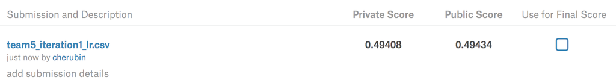

```python
Image(filename="1.png")
```

### Get results for Random Forest Model

Also, we apply the trained random forest model on the Kaggle test set and save the output as a csv file.

```python
predict_rf_result = model_rf.transform(test)
```

```python
rf_df_result = predict_rf_result.toPandas()[['id', 'prediction']].copy()
rf_df_result = rf_df_result.rename(columns={"prediction": "relevance"})
rf_df_result.to_csv('team5_iteration1_rf.csv', index = False)
```

The test prediction result we received from Kaggle for the random forest is 0.49023. This result is consistent with our cross validation results and lower than the RMSE from the linear regression model.

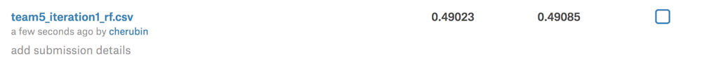

```python
from IPython.display import Image
Image(filename="2.png")
```

In conclusion for iteration 1 (baseline) approach, our best performance is training the random forest model on the 5 features (search_query_length','common_count_title', 'common_count_description','fuzz_title','fuzz_des'). This shows length of search query and the similarity between search query and product title & description plays an important part in relevance prediction. The similarity between product attributes and search query is not that important since it contains too many noise words and is not taken into consideration for raters when they are evaluting relevance.

Nevertheless, in this baseline approach, we only include plain-vanilla analysis on the similarity between search query and product details. We will further include the word2vec cosine similarity in the second iteration to improve prediction accuracy.

# Iteration 2 (Word2Vec Cosine Similarity)

In iteration 2, we improve the model by running the skip-gram word2vec model on the search term, product title, product description and attributes. Then, we use the cosine similarity between these word vectors to represent the similarity between search term and product details.

The skip-gram word2vec model has a main advantage over using the traditional tf-idf approach. TF-IDF represent documents into vectors only taking into consideration the frequency of a word occurring in documents. However, tf-idf neglects some words are inherently more related than others. For instance, the word "plastic" is more related to "glass" than "ceiling", since "plastic" and "glass" both represent the material of a product. The skip-gram word2vec model takes this factor into consideration and will bring more accurate results for our relevance prediction.

The skip-gram word2vec is implemented using a neural network architecture. We will only go through some basics of how it works and will not cover the details of this architecture. The skip-gram word2vec has two layers. The first hidden layer mainly performs the following task. Given a specific word in the middle of a sentence (the input word), look at the words nearby and pick one at random. The first layer is going to tell us the probability for every word in our vocabulary of being the nearby word that we chose. The output probabilities are going to relate to how likely it is find each vocabulary word nearby our input word. For example, the trained network is given the input word "plastic", the output probabilities are going to be much higher for word like "glass" than for unrelated words like "ceiling". We'll train the neural network to do this by feeding it word pairs in the search terms and product details (including product title, descriptions, attributes). For the second layer, it will take the results of the first layer as input and output vectors for every word in the vocabulary. Finally, we will calculate the cosine similarity between the word vectors as features in our model for prediction.

In this iteration, we have two parts: data loading and pre-processing & feature engineering. We will discuss these in more details.

## Data loading and pre-processing

First, we load the data from four csv files, and combine the product_description data with the train and test data seperately based on the product_uid.

```python
# -*- coding: utf-8 -*-
import pandas as pd
from nltk.stem import WordNetLemmatizer
from nltk.corpus import stopwords
#load the data
test_data = pd.read_csv("test.csv",encoding="ISO-8859-1")
train_data = pd.read_csv('train.csv', encoding="ISO-8859-1")
attributes = pd.read_csv("attributes.csv", encoding="ISO-8859-1")
product_description = pd.read_csv("product_descriptions.csv",encoding="ISO-8859-1")
```

```python
# merge with product_description
train_data_merge_descriptions = pd.merge(train_data, product_description,on = "product_uid", how = 'left')
test_data_merge_descriptions  = pd.merge(test_data, product_description,on = "product_uid", how = 'left')
```

Then, we choose lines in attribute data which have "MFG Brand Name" & "Material" value in "name" attribute. We merge these attributes information with the original train and test dataset. Also, we combine test and train data in one file here in order to provide a larger vocabulary base for our skip-gram word2vec.

```python
# explore attributes and filter those with names are "MFG Brand Name" & "Material"
pd.options.mode.chained_assignment = None
attributes = attributes[attributes['value'] != 'No']
brandName = attributes[attributes['name'] == "MFG Brand Name"]
material = attributes[attributes['name'] == "Material"]
material['value'] = material['value'].str.encode('utf-8')
material['value'] = material['value'].astype(str)
material.groupby('product_uid')['value'].apply(' '.join).reset_index()
material = material.drop_duplicates(subset = "product_uid")
```

```python
# merge train and test with brand and material
train_data_with_brand = pd.merge(train_data_merge_descriptions,brandName, on = "product_uid", how = 'left')
test_data_with_brand = pd.merge(test_data_merge_descriptions,brandName, on = "product_uid", how = 'left')
train_data = pd.merge(train_data_with_brand, material, on = "product_uid", how = 'left')
test_data = pd.merge(test_data_with_brand, material, on = "product_uid", how = 'left')
```

```python
frames = [train_data, test_data]
```

```python
all_data = pd.concat(frames)
```

Similar to the approaches in iteration 1, we process the words in the dataset by removing punctuation, lemmatizing and removing stop words. After this step, we have all data ready to train the skip-gram word2vec.

```python
all_data['name_x'] = all_data['name_x'].map(lambda x:replace_nan(x))
all_data['name_y'] = all_data['name_y'].map(lambda x:replace_nan(x))
all_data['product_description'] = all_data['product_description'].map(lambda x:replace_nan(x))
all_data['product_title'] = all_data['product_title'].map(lambda x:replace_nan(x))
all_data['search_term'] = all_data['search_term'].map(lambda x:replace_nan(x))
all_data['value_x'] = all_data['value_x'].map(lambda x:replace_nan(x))
all_data['value_y'] = all_data['value_y'].map(lambda x:replace_nan(x))
all_data['relevance'] = all_data['relevance'].map(lambda x:replace_nan(x))
```

```python
all_data['name_x_stem'] = all_data['name_x'].str.replace("[^\w\s]","")
all_data['name_y_stem'] = all_data['name_y'].str.replace("[^\w\s]","")
all_data['product_description_stem'] = all_data['product_description'].str.replace("[^\w\s]","")
all_data['product_title_stem'] = all_data['product_title'].str.replace("[^\w\s]","")
all_data['search_term_stem'] = all_data['search_term'].str.replace("[^\w\s]","")
all_data['value_x_stem'] = all_data['value_x'].str.replace("[^\w\s]","")
all_data['value_y_stem'] = all_data['value_y'].str.replace("[^\w\s]","")
```

```python
all_data['name_x_stem'] = all_data['name_x_stem'].map(lambda x:process_word(x))
all_data['name_y_stem'] = all_data['name_y_stem'].map(lambda x:process_word(x))
all_data['product_description_stem'] = all_data['product_description_stem'].map(lambda x:process_word(x))
all_data['product_title_stem'] = all_data['product_title_stem'].map(lambda x:process_word(x))
all_data['search_term_stem'] = all_data['search_term_stem'].map(lambda x:process_word(x))
all_data['value_x_stem'] = all_data['value_x_stem'].map(lambda x:process_word(x))
all_data['value_y_stem'] = all_data['value_y_stem'].map(lambda x:process_word(x))
```

```python
all_data['name_x_stem'] = all_data['name_x_stem'].map(lambda x:replace_nan(x))
all_data['name_y_stem'] = all_data['name_y_stem'].map(lambda x:replace_nan(x))
all_data['product_description_stem'] = all_data['product_description_stem'].map(lambda x:replace_nan(x))
all_data['product_title_stem'] = all_data['product_title_stem'].map(lambda x:replace_nan(x))
all_data['search_term_stem'] = all_data['search_term_stem'].map(lambda x:replace_nan(x))
all_data['value_x_stem'] = all_data['value_x_stem'].map(lambda x:replace_nan(x))
all_data['value_y_stem'] = all_data['value_y_stem'].map(lambda x:replace_nan(x))
```

```python
all_data.to_csv('all_data.csv')
```

## Training word2vec models - Method 1

Now we start to train the word2vec on our vocabulary, there are two methods of forming vocabulary for training the word2vec models. We first start from the basic method. In method 1, we simply treat the "search term", "product title", "product description", "product attribute" for each product as separate documents. There are two sets of vocabularies we can train in method 1: the vocabulary with processing and the vocabulary without processing.

First, we start from establishing the vocabulary with processed words for training the word2vec model.

```python
# word2Vec first and second vocab
st = all_data["search_term_stem"].tolist()
pt = all_data["product_title_stem"].tolist()
pd = all_data["product_description_stem"].tolist()
att_x = all_data["value_x_stem"].tolist()
att_y = all_data["value_y_stem"].tolist()
```

```python
first_vocab = list()
for i in range(len(st)):
    p = st[i].split()
    first_vocab.append(p)

for i in range(len(pt)):
    p = pt[i].split()
    first_vocab.append(p)

for i in range(len(pd)):
    p = pd[i].split()
    first_vocab.append(p)

for i in range(len(att_x)):
    p = att_x[i].split()
    first_vocab.append(p)

for i in range(len(att_y)):
    p = att_y[i].split()
    first_vocab.append(p)
```

Next, we set up the vocabulary with original (not processed) words for training the word2vec model.

```python
# word2Vec second vocab
st_ori = all_data["search_term"].tolist()
pt_ori = all_data["product_title"].tolist()
pd_ori = all_data["product_description"].tolist()
att_x_ori = all_data["value_x"].tolist()
att_y_ori = all_data["value_y"].tolist()
```

```python
second_vocab = list()
for i in range(len(st_ori)):
    p = st_ori[i].split()
    second_vocab.append(p)

for i in range(len(pt_ori)):
    p = pt_ori[i].split()
    second_vocab.append(p)

for i in range(len(pd_ori)):
    p = pd_ori[i].split()
    second_vocab.append(p)

for i in range(len(att_x_ori)):
    p = att_x_ori[i].split()
    second_vocab.append(p)

for i in range(len(att_y_ori)):
    p = att_y_ori[i].split()
    second_vocab.append(p)
```

After getting the vocabulary, we start to train the word2vec models using gensim library. Here we train two models using the different two vocabularies set above. Some simple explanation on the parameters we use: sg=1 refers to the skip-gram model we choose, window=10 refers to "the maximum distance between the current and predicted word within a sentence", negative=5 refers to "the number of noise words drawn for negative sampling", size=300 refers to "dimensionality of the feature vectors".

```python
import gensim
from gensim import models
```

```python
#train models
model0 = gensim.models.Word2Vec(first_vocab, sg=1, window=10, sample=1e-5, negative=5, size=300)
print("first model train done")
model1 = gensim.models.Word2Vec(second_vocab, sg=1, window=10, sample=1e-5, negative=5, size=300)
print("second model train done")
```

```
first model train done
second model train done
```

Then with the trained model, we apply cosine similarities on the word vectors. For each word2vec model, we get 10 features (cosine similarity score). These 10 features are: cosine similarity between "search term processed" and "product title processed", cosine similarity between "search term processed" and "product description processed", cosine similarity between "search term processed" and "product attribute x processed", cosine similarity between "search term processed" and "product attributes y processed", cosine similarity between "search term processed" and "all product details processed", cosine similarity between "search term original" and "product title original", cosine similarity between "search term original" and "product description original", cosine similarity between "search term original" and "product attribute x original", cosine similarity between "search term original" and "product attribute y original" and cosine similarity between "search term original" and "all product details original". Thus, after training these two word2vec models, we get 20 cosine similarity columns.

```python
def word2vec_cos_sim(model_list, search_term, feature):
    result = list()
    for model in model_list:
        result_single_model = list()
        for i in range(len(feature)):
            w1 = search_term[i].split()
            w2 = feature[i].split()
            d1=[]
            d2=[]
            for j in range(len(w1)):
                if w1[j] in model.wv.vocab:
                    d1.append(w1[j])
            for j in range(len(w2)):
                if w2[j] in model.wv.vocab:
                    d2.append(w2[j])
            if d1==[] or d2==[]:
                result_single_model.append(0)
            else:
                result_single_model.append(model.wv.n_similarity(d1,d2))
        result.append(result_single_model)
    return result
```

```python
model_list= [model0, model1]
sim_st_pt = word2vec_cos_sim(model_list, st, pt)
```

```python
all_data['cos_sim_st_pt_model0'] = sim_st_pt[0]
all_data['cos_sim_st_pt_model1'] = sim_st_pt[1]
```

```python
sim_st_pd = word2vec_cos_sim(model_list, st, pd)
all_data['cos_sim_st_pd_model0'] = sim_st_pd[0]
all_data['cos_sim_st_pd_model1'] = sim_st_pd[1]
```

```python
sim_st_att_x = word2vec_cos_sim(model_list, st, att_x)
all_data['cos_sim_st_att_x_model0'] = sim_st_att_x[0]
all_data['cos_sim_st_att_x_model1'] = sim_st_att_x[1]
```

```python
sim_st_att_y = word2vec_cos_sim(model_list, st, att_y)
all_data['cos_sim_st_att_y_model0'] = sim_st_att_y[0]
all_data['cos_sim_st_att_y_model1'] = sim_st_att_y[1]
```

```python
sim_st_pt_ori = word2vec_cos_sim(model_list, st_ori, pt_ori)
all_data['cos_sim_st_pt_ori_model0'] = sim_st_pt_ori[0]
all_data['cos_sim_st_pt_ori_model1'] = sim_st_pt_ori[1]
```

```python
sim_st_pd_ori = word2vec_cos_sim(model_list, st_ori, pd_ori)
all_data['cos_sim_st_pd_ori_model0'] = sim_st_pd_ori[0]
all_data['cos_sim_st_pd_ori_model1'] = sim_st_pd_ori[1]
```

```python
sim_st_att_x_ori = word2vec_cos_sim(model_list, st_ori, att_x_ori)
all_data['cos_sim_st_att_x_ori_model0'] = sim_st_att_x_ori[0]
all_data['cos_sim_st_att_x_ori_model1'] = sim_st_att_x_ori[1]
```

```python
sim_st_att_y_ori = word2vec_cos_sim(model_list, st_ori, att_y_ori)
all_data['cos_sim_st_att_y_ori_model0'] = sim_st_att_y_ori[0]
all_data['cos_sim_st_att_y_ori_model1'] = sim_st_att_y_ori[1]
```

```python
def word2vec_cos_sim_all(model_list, search_term, feature1, feature2, feature3, feature4):
    result = list()
    for model in model_list:
        result_single_model = list()
        for i in range(len(search_term)):
            w1 = search_term[i].split()
            w2 = feature1[i].split() + feature2[i].split() + feature3[i].split() + feature4[i].split()
            d1=[]
            d2=[]
            for j in range(len(w1)):
                if w1[j] in model.wv.vocab:
                    d1.append(w1[j])
            for j in range(len(w2)):
                if w2[j] in model.wv.vocab:
                    d2.append(w2[j])
            if d1==[] or d2==[]:
                result_single_model.append(0)
            else:
                result_single_model.append(model.wv.n_similarity(d1,d2))
        result.append(result_single_model)
    return result
```

```python
sim_st_all = word2vec_cos_sim_all(model_list, st, pt, pd, att_x, att_y)
all_data['cos_sim_st_all_model0'] = sim_st_all[0]
all_data['cos_sim_st_all_model1'] = sim_st_all[1]
```

```python
sim_st_all_ori = word2vec_cos_sim_all(model_list, st_ori, pt_ori, pd_ori, att_x_ori, att_y_ori)
all_data['cos_sim_st_all_ori_model0'] = sim_st_all_ori[0]
all_data['cos_sim_st_all_ori_model1'] = sim_st_all_ori[1]
```

## Training word2vec models - Method 2

Here, we use a second method of forming vocabulary for training the word2vec models. In this method, we merge the "search term", "product title", "product description", "product attribute" for each product as one document. Also, there are two sets of vocabularies we can train in method 2: the vocabulary with processing and the vocabulary without processing.

This method will have different results with method 1, since each document will be longer and contains all information about one single product. Adding this to our model will enhance our prediction accuracy.

```python
third_vocab = list()
for i in range(len(st)):
    p = st[i].split() + pt[i].split() + pd[i].split() + att_x[i].split() + att_y[i].split()
    third_vocab.append(p)
fourth_vocab = list()
for i in range(len(st)):
    p = st_ori[i].split() + pt_ori[i].split() + pd_ori[i].split() + att_x_ori[i].split() + att_y_ori[i].split()
    fourth_vocab.append(p)
```

```python
model2 = gensim.models.Word2Vec(third_vocab, sg=1, window=10, sample=1e-5, negative=5, size=300)
print("third model train done")
model3 = gensim.models.Word2Vec(fourth_vocab, sg=1, window=10, sample=1e-5, negative=5, size=300)
print("fourth model train done")
```

```
third model train done
fourth model train done
```

Similarly, we get 20 cosine similarities from these two models. Therefore, for the word2vec iteration, we have trained 4 models and added 40 features in total to prepare for the relevance prediction.

```python
model_list_1= [model2, model3]
sim_st_pt = word2vec_cos_sim(model_list_1, st, pt)
all_data['cos_sim_st_pt_model2'] = sim_st_pt[0]
all_data['cos_sim_st_pt_model3'] = sim_st_pt[1]
```

```python
sim_st_pd = word2vec_cos_sim(model_list_1, st, pd)
all_data['cos_sim_st_pd_model2'] = sim_st_pd[0]
all_data['cos_sim_st_pd_model3'] = sim_st_pd[1]
```

```python
sim_st_att_x = word2vec_cos_sim(model_list_1, st, att_x)
all_data['cos_sim_st_att_x_model2'] = sim_st_att_x[0]
all_data['cos_sim_st_att_x_model3'] = sim_st_att_x[1]
```

```python
sim_st_att_y = word2vec_cos_sim(model_list_1, st, att_y)
all_data['cos_sim_st_att_y_model2'] = sim_st_att_y[0]
all_data['cos_sim_st_att_y_model3'] = sim_st_att_y[1]
```

```python
sim_st_pt_ori = word2vec_cos_sim(model_list_1, st_ori, pt_ori)
all_data['cos_sim_st_pt_ori_model2'] = sim_st_pt_ori[0]
all_data['cos_sim_st_pt_ori_model3'] = sim_st_pt_ori[1]
```

```python
sim_st_pd_ori = word2vec_cos_sim(model_list_1, st_ori, pd_ori)
all_data['cos_sim_st_pd_ori_model2'] = sim_st_pd_ori[0]
all_data['cos_sim_st_pd_ori_model3'] = sim_st_pd_ori[1]
```

```python
sim_st_att_x_ori = word2vec_cos_sim(model_list_1, st_ori, att_x_ori)
all_data['cos_sim_st_att_x_ori_model2'] = sim_st_att_x_ori[0]
all_data['cos_sim_st_att_x_ori_model3'] = sim_st_att_x_ori[1]
```

```python
sim_st_att_y_ori = word2vec_cos_sim(model_list_1, st_ori, att_y_ori)
all_data['cos_sim_st_att_y_ori_model2'] = sim_st_att_y_ori[0]
all_data['cos_sim_st_att_y_ori_model3'] = sim_st_att_y_ori[1]
```

```python
sim_st_all = word2vec_cos_sim_all(model_list_1, st, pt, pd, att_x, att_y)
all_data['cos_sim_st_all_model2'] = sim_st_all[0]
all_data['cos_sim_st_all_model3'] = sim_st_all[1]
```

```python
sim_st_all_ori = word2vec_cos_sim_all(model_list_1, st_ori, pt_ori, pd_ori, att_x_ori, att_y_ori)
all_data['cos_sim_st_all_ori_model2'] = sim_st_all_ori[0]
all_data['cos_sim_st_all_ori_model3'] = sim_st_all_ori[1]
```

## Saving word2vec results

Finally, we split the dataset into train and test files and save the 40 features into csv.

```python
import numpy as np
```

```python
all_data_split = np.split(all_data, [74067], axis=0)
```

```python
train_word2vec = all_data_split[0]
```

```python
test_word2vec = all_data_split[1]
```

```python
train_word2vec.to_csv('train_word2vec.csv')
```

```python
test_word2vec.to_csv('test_word2vec.csv')
```

# Predicting relevance using features from iteration 1 and iteration 2

Finally, we wrap our project by predicting relevance using all important features from iteration 1 and iteration 2 to get the test RMSE score on Kaggle.

## Combining all features from iteration 1 and iteration 2

First, we combine all the features from iteration 1 and 2 into two dataframes: the train_final and test_final. A snippet of the two dataframes are provided as below.

```python
pipeline_1_train = pd.read_csv("train_iteration_1.csv")
pipeline_1_test = pd.read_csv("test_iteration_1.csv")
pipeline_2_train = pd.read_csv("train_word2vec.csv")
pipeline_2_test = pd.read_csv("test_word2vec.csv")
```

```python
train_final = pd.concat([pipeline_1_train, pipeline_2_train], axis=1)
train_final = train_final.drop(['Unnamed: 0'],axis=1)
```

```python
train_final
```

|  | id | product_uid | product_title | search_term | relevance | product_description | search_query_length | search_title_des | common_count_title | common_count_description | ... | cos_sim_st_pd_ori_model2 | cos_sim_st_pd_ori_model3 | cos_sim_st_att_x_ori_model2 | cos_sim_st_att_x_ori_model3 | cos_sim_st_att_y_ori_model2 | cos_sim_st_att_y_ori_model3 | cos_sim_st_all_model2 | cos_sim_st_all_model3 | cos_sim_st_all_ori_model2 | cos_sim_st_all_ori_model3 |
| --- | --- | --- | --- | --- | --- | --- | --- | --- | --- | --- | --- | --- | --- | --- | --- | --- | --- | --- | --- | --- | --- |
| 0 | 2 | 100001 | simpson strongtie 12gauge angle | angle bracket | 3.00 | angle make joint stronger also provide consist... | 2 | angle bracket\tsimpson strongtie 12gauge angle... | 1 | 1 | ... | 0.513301 | 0.434092 | 0.0 | 0.239320 | 0.0 | 0.221435 | 0.520956 | 0.512520 | 0.513301 | 0.441588 |
| 1 | 3 | 100001 | simpson strongtie 12gauge angle | l bracket | 2.50 | angle make joint stronger also provide consist... | 2 | l bracket\tsimpson strongtie 12gauge angle\tan... | 1 | 1 | ... | 0.438259 | 0.344890 | 0.0 | 0.231630 | 0.0 | 0.214150 | 0.402346 | 0.366049 | 0.438259 | 0.354956 |
| 2 | 9 | 100002 | behr premium textured deckover 1gal sc141 tugb... | deck | 3.00 | behr premium textured deckover innovative soli... | 1 | deck\tbehr premium textured deckover 1gal sc14... | 1 | 1 | ... | 0.496025 | 0.478354 | 0.0 | 0.363300 | 0.0 | 0.000000 | 0.517111 | 0.440842 | 0.496025 | 0.484013 |
| 3 | 16 | 100005 | delta vero 1handle shower faucet trim kit chro... | rain shower head | 2.33 | update bathroom delta vero singlehandle shower... | 3 | rain shower head\tdelta vero 1handle shower fa... | 1 | 1 | ... | 0.526526 | 0.545023 | 0.0 | 0.318394 | 0.0 | 0.000000 | 0.583438 | 0.570381 | 0.526526 | 0.558698 |
| 4 | 17 | 100005 | delta vero 1handle shower faucet trim kit chro... | shower faucet | 2.67 | update bathroom delta vero singlehandle shower... | 2 | shower faucet\tdelta vero 1handle shower fauce... | 2 | 2 | ... | 0.571413 | 0.663975 | 0.0 | 0.433399 | 0.0 | 0.000000 | 0.701437 | 0.694238 | 0.571413 | 0.692497 |
| 5 | 18 | 100006 | whirlpool 19 cu ft range convection microwave ... | convection otr | 3.00 | achieving delicious result almost effortless w... | 2 | convection otr\twhirlpool 19 cu ft range conve... | 1 | 2 | ... | 0.710558 | 0.617705 | 0.0 | 0.380228 | 0.0 | 0.000000 | 0.722890 | 0.678365 | 0.710558 | 0.631338 |
| 6 | 20 | 100006 | whirlpool 19 cu ft range convection microwave ... | microwave stove | 2.67 | achieving delicious result almost effortless w... | 2 | microwave stove\twhirlpool 19 cu ft range conv... | 1 | 1 | ... | 0.633620 | 0.648817 | 0.0 | 0.351241 | 0.0 | 0.000000 | 0.639295 | 0.645288 | 0.633620 | 0.659948 |
| 7 | 21 | 100006 | whirlpool 19 cu ft range convection microwave ... | microwave | 3.00 | achieving delicious result almost effortless w... | 1 | microwave\twhirlpool 19 cu ft range convection... | 1 | 1 | ... | 0.000000 | 0.476337 | 0.0 | 0.239570 | 0.0 | 0.000000 | 0.635417 | 0.632739 | 0.000000 | 0.488218 |
| 8 | 23 | 100007 | lithonia lighting quantum 2light black led eme... | emergency light | 2.67 | quantum adjustable 2light led black emergency ... | 2 | emergency light\tlithonia lighting quantum 2li... | 2 | 2 | ... | 0.558091 | 0.563591 | 0.0 | 0.424223 | 0.0 | 0.149728 | 0.671667 | 0.613559 | 0.558091 | 0.588084 |
| 9 | 27 | 100009 | house fara 34 x 3 x 8 ft mdf fluted casing | mdf 34 | 3.00 | get house fara 34 x 3 x 8 ft mdf fluted casing... | 2 | mdf 34\thouse fara 34 x 3 x 8 ft mdf fluted ca... | 2 | 2 | ... | 0.437576 | 0.569272 | 0.0 | 0.489214 | 0.0 | 0.427652 | 0.703753 | 0.683169 | 0.431452 | 0.640581 |
| 10 | 34 | 100010 | valley view industry metal stake 4pack | steele stake | 2.67 | valley view industry metal stake 4pack 9 galva... | 2 | steele stake\tvalley view industry metal stake... | 1 | 1 | ... | 0.561463 | 0.532757 | 0.0 | 0.308148 | 0.0 | 0.118074 | 0.703852 | 0.635577 | 0.561463 | 0.538646 |
| 11 | 35 | 100011 | toro personal pace recycler 22 variable speed ... | briggs stratton lawn mower | 3.00 | recycler 22 personal pace variable speed selfp... | 4 | briggs stratton lawn mower\ttoro personal pace... | 4 | 4 | ... | 0.720027 | 0.791961 | 0.0 | 0.561624 | 0.0 | 0.000000 | 0.782414 | 0.801967 | 0.720515 | 0.816942 |
| 12 | 37 | 100011 | toro personal pace recycler 22 variable speed ... | gas mowe | 3.00 | recycler 22 personal pace variable speed selfp... | 2 | gas mowe\ttoro personal pace recycler 22 varia... | 2 | 2 | ... | 0.644692 | 0.595319 | 0.0 | 0.396827 | 0.0 | 0.000000 | 0.675840 | 0.624913 | 0.646749 | 0.614448 |
| 13 | 38 | 100011 | toro personal pace recycler 22 variable speed ... | honda mower | 2.00 | recycler 22 personal pace variable speed selfp... | 2 | honda mower\ttoro personal pace recycler 22 va... | 1 | 1 | ... | 0.678820 | 0.725887 | 0.0 | 0.648150 | 0.0 | 0.000000 | 0.714318 | 0.770313 | 0.677927 | 0.755198 |
| 14 | 48 | 100012 | hampton bay caramel simple weave bamboo rollup... | hampton bay chestnut pull shade | 2.67 | 96 wide caramel simple weave rollup bamboo sha... | 5 | hampton bay chestnut pull shade\thampton bay c... | 3 | 2 | ... | 0.638129 | 0.648180 | 0.0 | 0.719426 | 0.0 | 0.378358 | 0.670486 | 0.672976 | 0.637782 | 0.668594 |
| 15 | 51 | 100013 | insinkerator sinktop switch single outlet insi... | disposer | 2.67 | insinkerator sinktop switch single outlet insi... | 1 | disposer\tinsinkerator sinktop switch single o... | 1 | 1 | ... | 0.335703 | 0.400946 | 0.0 | 0.616593 | 0.0 | 0.000000 | 0.521172 | 0.417874 | 0.335703 | 0.455727 |
| 16 | 65 | 100016 | sunjoy calais 8 ft x 5 ft x 8 ft steel tile fa... | grill gazebo | 3.00 | make grilling great handsome functional grill ... | 2 | grill gazebo\tsunjoy calais 8 ft x 5 ft x 8 ft... | 2 | 2 | ... | 0.744580 | 0.660905 | 0.0 | 0.609208 | 0.0 | 0.000000 | 0.747327 | 0.762385 | 0.729518 | 0.677934 |
| 17 | 69 | 100017 | md building product 36 x 36 cloverleaf aluminu... | door guard | 1.00 | md building product 36 x 36 x 150 aluminum clo... | 2 | door guard\tmd building product 36 x 36 clover... | 0 | 1 | ... | 0.511471 | 0.451901 | 0.0 | 0.257460 | 0.0 | 0.187734 | 0.444614 | 0.454888 | 0.506006 | 0.448514 |
| 18 | 75 | 100017 | md building product 36 x 36 cloverleaf aluminu... | metal plate cover gcfi | 1.67 | md building product 36 x 36 x 150 aluminum clo... | 4 | metal plate cover gcfi\tmd building product 36... | 0 | 0 | ... | 0.496552 | 0.524855 | 0.0 | 0.264566 | 0.0 | 0.283744 | 0.526414 | 0.532494 | 0.474900 | 0.517529 |
| 19 | 81 | 100017 | md building product 36 x 36 cloverleaf aluminu... | radiator grate | 2.33 | md building product 36 x 36 x 150 aluminum clo... | 2 | radiator grate\tmd building product 36 x 36 cl... | 0 | 0 | ... | 0.412483 | 0.444665 | 0.0 | 0.344135 | 0.0 | 0.230431 | 0.460294 | 0.432383 | 0.399381 | 0.459173 |
| 20 | 85 | 100017 | md building product 36 x 36 cloverleaf aluminu... | window screen | 2.33 | md building product 36 x 36 x 150 aluminum clo... | 2 | window screen\tmd building product 36 x 36 clo... | 0 | 2 | ... | 0.000000 | 0.469244 | 0.0 | 0.339870 | 0.0 | 0.240405 | 0.523576 | 0.505348 | 0.000000 | 0.475726 |
| 21 | 88 | 100019 | house fara 8 linear ft mdf overlapping wainsco... | 1x1 rail decorative wood | 1.33 | house fara 8 linear ft primed mdf overlapping ... | 4 | 1x1 rail decorative wood\thouse fara 8 linear ... | 0 | 1 | ... | 0.744707 | 0.727409 | 0.0 | 0.468767 | 0.0 | 0.354759 | 0.677200 | 0.720327 | 0.744410 | 0.716701 |
| 22 | 90 | 100019 | house fara 8 linear ft mdf overlapping wainsco... | 48 beadboard paneling | 2.67 | house fara 8 linear ft primed mdf overlapping ... | 3 | 48 beadboard paneling\thouse fara 8 linear ft ... | 1 | 1 | ... | 0.590432 | 0.657272 | 0.0 | 0.465608 | 0.0 | 0.391153 | 0.715867 | 0.700540 | 0.588051 | 0.681724 |
| 23 | 92 | 100019 | house fara 8 linear ft mdf overlapping wainsco... | 4x8wood paneling | 2.33 | house fara 8 linear ft primed mdf overlapping ... | 2 | 4x8wood paneling\thouse fara 8 linear ft mdf o... | 1 | 1 | ... | 0.619286 | 0.586500 | 0.0 | 0.396538 | 0.0 | 0.339495 | 0.686040 | 0.643832 | 0.616128 | 0.605622 |
| 24 | 101 | 100019 | house fara 8 linear ft mdf overlapping wainsco... | mdf 4x8 | 1.33 | house fara 8 linear ft primed mdf overlapping ... | 2 | mdf 4x8\thouse fara 8 linear ft mdf overlappin... | 1 | 1 | ... | 0.482561 | 0.576823 | 0.0 | 0.465104 | 0.0 | 0.460120 | 0.686397 | 0.666581 | 0.490233 | 0.627833 |
| 25 | 105 | 100019 | house fara 8 linear ft mdf overlapping wainsco... | wainscot chair rail | 2.33 | house fara 8 linear ft primed mdf overlapping ... | 3 | wainscot chair rail\thouse fara 8 linear ft md... | 1 | 3 | ... | 0.741122 | 0.710709 | 0.0 | 0.516835 | 0.0 | 0.431705 | 0.758736 | 0.727376 | 0.735477 | 0.725090 |
| 26 | 106 | 100019 | house fara 8 linear ft mdf overlapping wainsco... | wainscot plank paneling | 2.33 | house fara 8 linear ft primed mdf overlapping ... | 3 | wainscot plank paneling\thouse fara 8 linear f... | 2 | 2 | ... | 0.643273 | 0.610704 | 0.0 | 0.434946 | 0.0 | 0.380583 | 0.735803 | 0.677473 | 0.639775 | 0.635093 |
| 27 | 113 | 100021 | 1804 dual spray half pattern 4 popup spray head | lawn sprkinler | 2.00 | installed park backyard across globe rain bird... | 2 | lawn sprkinler\t1804 dual spray half pattern 4... | 0 | 1 | ... | 0.650256 | 0.610592 | 0.0 | 0.360582 | 0.0 | 0.000000 | 0.660442 | 0.644825 | 0.650501 | 0.614828 |
| 28 | 114 | 100021 | 1804 dual spray half pattern 4 popup spray head | rainbird sprinkler | 2.33 | installed park backyard across globe rain bird... | 2 | rainbird sprinkler\t1804 dual spray half patte... | 0 | 1 | ... | 0.676869 | 0.626385 | 0.0 | 0.654101 | 0.0 | 0.000000 | 0.696263 | 0.639692 | 0.677753 | 0.649586 |
| 29 | 117 | 100022 | samsung 42 cu ft front load washer steam white... | platform washer | 2.67 | samsung 42 cu ft front load washer steam white... | 2 | platform washer\tsamsung 42 cu ft front load w... | 1 | 1 | ... | 0.000000 | 0.521314 | 0.0 | 0.425632 | 0.0 | 0.000000 | 0.517010 | 0.545718 | 0.000000 | 0.544014 |
| ... | ... | ... | ... | ... | ... | ... | ... | ... | ... | ... | ... | ... | ... | ... | ... | ... | ... | ... | ... | ... | ... |
| 74037 | 221398 | 206588 | cake bos decorating tool 3piece plastic icing ... | plastic 3 piece nativity set | 1.67 | perfect trio decorating bag cake bos decoratin... | 5 | plastic 3 piece nativity set\tcake bos decorat... | 4 | 4 | ... | 0.722164 | 0.704751 | 0.0 | 0.349872 | 0.0 | 0.000000 | 0.711975 | 0.682881 | 0.722164 | 0.704579 |
| 74038 | 221400 | 206589 | husky universal passthrough mechanic tool set ... | pas curtain ring | 1.33 | husky 126piece passthrough socket ratchet set ... | 3 | pas curtain ring\thusky universal passthrough ... | 1 | 2 | ... | 0.533873 | 0.556014 | 0.0 | 0.206524 | 0.0 | 0.000000 | 0.502506 | 0.537122 | 0.533873 | 0.556094 |
| 74039 | 221401 | 206590 | crosley lafayette low profile tv stand black | crosley lafayette kf30024bwh | 2.33 | enhance living space crosleys impeccablycrafte... | 3 | crosley lafayette kf30024bwh\tcrosley lafayett... | 2 | 1 | ... | 0.625432 | 0.647901 | 0.0 | 0.704108 | 0.0 | 0.270443 | 0.747430 | 0.673504 | 0.625432 | 0.685600 |
| 74040 | 221404 | 206593 | rustoleum automotive 8 oz special white auto t... | dremel auto rust | 2.33 | rustoleum automotive touchup aerosol ideal use... | 3 | dremel auto rust\trustoleum automotive 8 oz sp... | 2 | 2 | ... | 0.412322 | 0.487894 | 0.0 | 0.418542 | 0.0 | 0.000000 | 0.498393 | 0.516160 | 0.410810 | 0.524936 |
| 74041 | 221405 | 206594 | foremost tide 33 35 x 65 framed pivot shower d... | privacy glass pivot door | 2.67 | whether designing new bathroom renovating curr... | 4 | privacy glass pivot door\tforemost tide 33 35 ... | 3 | 3 | ... | 0.772831 | 0.729664 | 0.0 | 0.277349 | 0.0 | 0.000000 | 0.810083 | 0.791721 | 0.768167 | 0.732203 |
| 74042 | 221407 | 206596 | bali cuttosize crown 35 pvc louver set 9pack | alabaster blind 39x72 alvin | 1.67 | bali cuttosize vertical blind offer beautiful ... | 4 | alabaster blind 39x72 alvin\tbali cuttosize cr... | 0 | 1 | ... | 0.610031 | 0.657041 | 0.0 | 0.602317 | 0.0 | 0.196840 | 0.721067 | 0.688013 | 0.610031 | 0.671000 |
| 74043 | 221408 | 206597 | home fashion technology 14 x 59 solid wood lou... | exterior shutter movable louver | 3.00 | instantly add value style home solid prime pin... | 4 | exterior shutter movable louver\thome fashion ... | 3 | 3 | ... | 0.566899 | 0.578693 | 0.0 | 0.421362 | 0.0 | 0.411132 | 0.699719 | 0.638758 | 0.562744 | 0.620331 |
| 74044 | 221409 | 206598 | newport coastal photo eye replacement | lightsensor | 2.67 | newport coastal photo eye replacement convenie... | 1 | lightsensor\tnewport coastal photo eye replace... | 0 | 0 | ... | 0.732237 | 0.675842 | 0.0 | 0.393814 | 0.0 | 0.129388 | 0.776748 | 0.680022 | 0.732237 | 0.697449 |
| 74045 | 221411 | 206599 | hydronix 12 x 212 inline coconut carbon filter | bypass 12 water filter | 1.33 | already inline filter want replacement higher ... | 4 | bypass 12 water filter\thydronix 12 x 212 inli... | 2 | 3 | ... | 0.719097 | 0.662223 | 0.0 | 0.000000 | 0.0 | 0.000000 | 0.754410 | 0.729754 | 0.727032 | 0.684006 |
| 74046 | 221412 | 206600 | worx 12 nicd 24volt 35 hour charger grass trim... | ni24v | 2.00 | flexibility best worx 2in1 12 grass trimmeredg... | 1 | ni24v\tworx 12 nicd 24volt 35 hour charger gra... | 0 | 0 | ... | 0.000000 | 0.000000 | 0.0 | 0.000000 | 0.0 | 0.000000 | 0.000000 | 0.000000 | 0.000000 | 0.000000 |
| 74047 | 221413 | 206601 | 3m tekk protection white vented hard hat ratch... | hard hat mining | 1.67 | 3m tekk protection vented pro ratchet hard hat... | 3 | hard hat mining\t3m tekk protection white vent... | 2 | 2 | ... | 0.428666 | 0.639453 | 0.0 | 0.433843 | 0.0 | 0.225407 | 0.644531 | 0.568436 | 0.428666 | 0.654560 |
| 74048 | 221415 | 206602 | hylite glass block fixed vinyl window driftwoo... | replace broken glass vinyl window | 2.00 | excellent privacy decorative solution area hom... | 5 | replace broken glass vinyl window\thylite glas... | 3 | 2 | ... | 0.651185 | 0.745442 | 0.0 | 0.476012 | 0.0 | 0.000000 | 0.688620 | 0.659417 | 0.651185 | 0.753886 |
| 74049 | 221416 | 206603 | westinghouse 3 ft oil rubbed bronze beaded cha... | ceiling fan chain cord | 1.00 | westinghouse lighting oil rubbed bronze beaded... | 4 | ceiling fan chain cord\twestinghouse 3 ft oil ... | 1 | 3 | ... | 0.691830 | 0.739148 | 0.0 | 0.477234 | 0.0 | 0.000000 | 0.738472 | 0.734393 | 0.691112 | 0.741232 |
| 74050 | 221419 | 206606 | behr premium plus icc101 florentine clay zero ... | florentine clay | 2.33 | behr premium plus zero voc selfpriming interio... | 2 | florentine clay\tbehr premium plus icc101 flor... | 2 | 0 | ... | 0.442024 | 0.459109 | 0.0 | 0.396216 | 0.0 | 0.000000 | 0.495650 | 0.512217 | 0.442024 | 0.483776 |
| 74051 | 221420 | 206607 | home legend palace oak light 34 thick x 34 wid... | trim home light | 2.00 | quarter round typically placed front existing ... | 3 | trim home light\thome legend palace oak light ... | 2 | 1 | ... | 0.601930 | 0.662351 | 0.0 | 0.349128 | 0.0 | 0.244281 | 0.633014 | 0.619629 | 0.591239 | 0.648268 |
| 74052 | 221422 | 206609 | whitehaus collection isabella wallmounted bath... | whitehaus bathroom sinl | 2.33 | beautify bathroom powder room whitehaus isabel... | 3 | whitehaus bathroom sinl\twhitehaus collection ... | 2 | 2 | ... | 0.742864 | 0.740469 | 0.0 | 0.635618 | 0.0 | 0.413621 | 0.853290 | 0.799363 | 0.742864 | 0.802134 |
| 74053 | 221423 | 206610 | champion power equipment 65 hp gaspowered 3 se... | 65 hp gas generator | 2.33 | champion power equipment 3 semitrash pump powe... | 4 | 65 hp gas generator\tchampion power equipment ... | 3 | 0 | ... | 0.666064 | 0.619354 | 0.0 | 0.486509 | 0.0 | 0.000000 | 0.732456 | 0.678052 | 0.660203 | 0.654062 |
| 74054 | 221426 | 206613 | everbilt 4 white wall guard | splash guard wall | 2.00 | everbilt 4 wall guard help prevent damage wall... | 3 | splash guard wall\teverbilt 4 white wall guard... | 2 | 2 | ... | 0.497708 | 0.534029 | 0.0 | 0.096654 | 0.0 | 0.231198 | 0.568603 | 0.620882 | 0.502500 | 0.543903 |
| 74055 | 221427 | 206614 | daltile villa valleta calais spring 18 x 18 po... | spicewood spring floor tile | 1.67 | daltile villa valleta calais spring porcelain ... | 4 | spicewood spring floor tile\tdaltile villa val... | 3 | 3 | ... | 0.680418 | 0.608569 | 0.0 | 0.413739 | 0.0 | 0.000000 | 0.649865 | 0.729644 | 0.681830 | 0.629292 |
| 74056 | 221432 | 206619 | home style stone harbor 51 round 7piece slate ... | laguna porcelin tile | 2.00 | stone harbor 7piece dining set includes large ... | 3 | laguna porcelin tile\thome style stone harbor ... | 2 | 2 | ... | 0.630327 | 0.622630 | 0.0 | 0.367242 | 0.0 | 0.000000 | 0.696407 | 0.619067 | 0.628581 | 0.640426 |
| 74057 | 221434 | 206621 | crown bolt m632 x 90 mm internal hex socket ca... | m6 screw 90mm | 2.67 | crown bolt metric socket cap screw ideal appli... | 3 | m6 screw 90mm\tcrown bolt m632 x 90 mm interna... | 2 | 2 | ... | 0.734191 | 0.682644 | 0.0 | 0.515958 | 0.0 | 0.000000 | 0.776219 | 0.745275 | 0.726257 | 0.717543 |
| 74058 | 221443 | 206627 | 25 stainless tipout sink front tray | sink tipout tray | 3.00 | add little luxury otherwise wasted space stain... | 3 | sink tipout tray\t25 stainless tipout sink fro... | 3 | 2 | ... | 0.557791 | 0.700417 | 0.0 | 0.000000 | 0.0 | 0.000000 | 0.818103 | 0.708452 | 0.557123 | 0.730145 |
| 74059 | 221449 | 206631 | masonite new three quarter oval lite primed sm... | fiberglass front door masonite | 3.00 | create inviting stylish entryway masonite new ... | 4 | fiberglass front door masonite\tmasonite new t... | 4 | 3 | ... | 0.640628 | 0.727034 | 0.0 | 0.517230 | 0.0 | 0.340500 | 0.803422 | 0.764419 | 0.640628 | 0.748832 |
| 74060 | 221450 | 206632 | lilly miller ultragreen 1 gal vitamin b1 plant... | starter fertillzer | 2.00 | lilly miller ultragreen vitamin b1 plant start... | 2 | starter fertillzer\tlilly miller ultragreen 1 ... | 1 | 1 | ... | 0.480813 | 0.486340 | 0.0 | 0.443838 | 0.0 | 0.000000 | 0.596592 | 0.559416 | 0.483176 | 0.525020 |
| 74061 | 221455 | 206637 | schluter rondec stainless steel 38 x 1 metal 9... | rondec stainless steel 38 edge protection | 3.00 | evro100e prefabricated corner rondec eliminate... | 6 | rondec stainless steel 38 edge protection\tsch... | 4 | 5 | ... | 0.678479 | 0.688113 | 0.0 | 0.353533 | 0.0 | 0.275645 | 0.829367 | 0.748850 | 0.668792 | 0.707034 |
| 74062 | 221457 | 206638 | atlantic windowpane 576 cd 192 dvd bluray game... | tv riser glass | 1.00 | atlantic inc 94835722 uniquely designed maximu... | 3 | tv riser glass\tatlantic windowpane 576 cd 192... | 1 | 1 | ... | 0.571518 | 0.544123 | 0.0 | 0.401850 | 0.0 | 0.262652 | 0.639079 | 0.545443 | 0.571005 | 0.590723 |
| 74063 | 221458 | 206639 | philip 40watt halogen r20 flood light bulb 12pack | r20 halogen light | 3.00 | philip energy advantage lamp use le energy mai... | 3 | r20 halogen light\tphilip 40watt halogen r20 f... | 3 | 2 | ... | 0.733355 | 0.731458 | 0.0 | 0.545114 | 0.0 | 0.000000 | 0.794535 | 0.834053 | 0.733355 | 0.769660 |
| 74064 | 221463 | 206641 | schlage camelot inactive aged bronze handleset... | schlage lock siena half dummy knob | 2.33 | schlage camelot inactive aged bronze handleset... | 6 | schlage lock siena half dummy knob\tschlage ca... | 1 | 3 | ... | 0.634814 | 0.692193 | 0.0 | 0.567552 | 0.0 | 0.439518 | 0.755853 | 0.658520 | 0.634814 | 0.720991 |
| 74065 | 221471 | 206648 | plastec 11 x 24 rose garden wall decor steel | zen garden decor | 3.00 | rose garden inspired popular early 20th centur... | 3 | zen garden decor\tplastec 11 x 24 rose garden ... | 2 | 2 | ... | 0.571170 | 0.656444 | 0.0 | 0.000000 | 0.0 | 0.172168 | 0.704898 | 0.733317 | 0.601649 | 0.689036 |
| 74066 | 221473 | 206650 | lichtenberg pool blue 918 millennial ryan heat... | fine sheer curtain 63 inch | 2.33 | 918 millennial ryan heathered texture semishee... | 5 | fine sheer curtain 63 inch\tlichtenberg pool b... | 3 | 2 | ... | 0.638283 | 0.633003 | 0.0 | 0.654533 | 0.0 | 0.387380 | 0.766102 | 0.742952 | 0.676783 | 0.706498 |

74067 rows × 73 columns

```python
train_final.to_csv('train_final.csv', index = False)
```

```python
test_final = pd.concat([pipeline_1_test, pipeline_2_test], axis=1)
test_final = test_final.drop(['Unnamed: 0'],axis=1)
```

```python
test_final
```

|  | id | product_uid | product_title | search_term | product_description | search_query_length | search_title_des | common_count_title | common_count_description | fuzz_title | ... | cos_sim_st_pd_ori_model2 | cos_sim_st_pd_ori_model3 | cos_sim_st_att_x_ori_model2 | cos_sim_st_att_x_ori_model3 | cos_sim_st_att_y_ori_model2 | cos_sim_st_att_y_ori_model3 | cos_sim_st_all_model2 | cos_sim_st_all_model3 | cos_sim_st_all_ori_model2 | cos_sim_st_all_ori_model3 |
| --- | --- | --- | --- | --- | --- | --- | --- | --- | --- | --- | --- | --- | --- | --- | --- | --- | --- | --- | --- | --- | --- |
| 0 | 1 | 100001 | simpson strongtie 12gauge angle | 90 degree bracket | angle make joint stronger also provide consist... | 3 | 90 degree bracket\tsimpson strongtie 12gauge a... | 0 | 1 | 25 | ... | 0.524059 | 0.484549 | 0.000000 | 0.214184 | 0.0 | 0.232651 | 0.483732 | 0.518739 | 0.524059 | 0.481466 |
| 1 | 4 | 100001 | simpson strongtie 12gauge angle | metal l bracket | angle make joint stronger also provide consist... | 3 | metal l bracket\tsimpson strongtie 12gauge ang... | 1 | 1 | 30 | ... | 0.508715 | 0.442726 | 0.000000 | 0.214157 | 0.0 | 0.273759 | 0.488925 | 0.462858 | 0.508715 | 0.444550 |
| 2 | 5 | 100001 | simpson strongtie 12gauge angle | simpson sku able | angle make joint stronger also provide consist... | 3 | simpson sku able\tsimpson strongtie 12gauge an... | 1 | 1 | 61 | ... | 0.485521 | 0.539562 | 0.000000 | 0.566015 | 0.0 | 0.241527 | 0.619976 | 0.583987 | 0.485521 | 0.570431 |
| 3 | 6 | 100001 | simpson strongtie 12gauge angle | simpson strong tie | angle make joint stronger also provide consist... | 3 | simpson strong tie\tsimpson strongtie 12gauge ... | 3 | 3 | 69 | ... | 0.518940 | 0.572875 | 0.000000 | 0.627626 | 0.0 | 0.256093 | 0.697405 | 0.612595 | 0.518940 | 0.604600 |
| 4 | 7 | 100001 | simpson strongtie 12gauge angle | simpson strong tie hcc668 | angle make joint stronger also provide consist... | 4 | simpson strong tie hcc668\tsimpson strongtie 1... | 3 | 3 | 64 | ... | 0.571625 | 0.642545 | 0.000000 | 0.659495 | 0.0 | 0.304130 | 0.746575 | 0.662077 | 0.571625 | 0.675054 |
| 5 | 8 | 100001 | simpson strongtie 12gauge angle | wood connector | angle make joint stronger also provide consist... | 2 | wood connector\tsimpson strongtie 12gauge angl... | 0 | 1 | 22 | ... | 0.362886 | 0.552004 | 0.000000 | 0.333628 | 0.0 | 0.301868 | 0.579173 | 0.600634 | 0.362886 | 0.555305 |
| 6 | 10 | 100003 | sterling ensemble 3314 x 60 x 7514 bath shower... | bath shower kit | classic architecture meet contemporary design ... | 3 | bath shower kit\tsterling ensemble 3314 x 60 x... | 3 | 1 | 100 | ... | 0.560485 | 0.636415 | 0.000000 | 0.398571 | 0.0 | 0.203968 | 0.624347 | 0.658833 | 0.573358 | 0.676340 |
| 7 | 11 | 100003 | sterling ensemble 3314 x 60 x 7514 bath shower... | bath drain kit | classic architecture meet contemporary design ... | 3 | bath drain kit\tsterling ensemble 3314 x 60 x ... | 3 | 1 | 100 | ... | 0.553815 | 0.549410 | 0.000000 | 0.385589 | 0.0 | 0.211556 | 0.623893 | 0.634213 | 0.569044 | 0.595093 |
| 8 | 12 | 100003 | sterling ensemble 3314 x 60 x 7514 bath shower... | one piece tub shower | classic architecture meet contemporary design ... | 4 | one piece tub shower\tsterling ensemble 3314 x... | 1 | 0 | 46 | ... | 0.603773 | 0.602407 | 0.000000 | 0.402226 | 0.0 | 0.229464 | 0.664304 | 0.674490 | 0.622184 | 0.642447 |
| 9 | 13 | 100004 | grape solar 265watt polycrystalline solar pane... | solar panel | grape solar 265watt polycrystalline pv solar p... | 2 | solar panel\tgrape solar 265watt polycrystalli... | 2 | 2 | 100 | ... | 0.552014 | 0.637544 | 0.000000 | 0.644717 | 0.0 | 0.000000 | 0.756643 | 0.725252 | 0.552014 | 0.672803 |
| 10 | 14 | 100005 | delta vero 1handle shower faucet trim kit chro... | 1 handle shower delta trim kit | update bathroom delta vero singlehandle shower... | 6 | 1 handle shower delta trim kit\tdelta vero 1ha... | 6 | 6 | 82 | ... | 0.675402 | 0.713769 | 0.000000 | 0.587371 | 0.0 | 0.000000 | 0.795353 | 0.807745 | 0.675402 | 0.757046 |
| 11 | 15 | 100005 | delta vero 1handle shower faucet trim kit chro... | delta ashland shower faucet | update bathroom delta vero singlehandle shower... | 4 | delta ashland shower faucet\tdelta vero 1handl... | 3 | 3 | 83 | ... | 0.561928 | 0.659499 | 0.000000 | 0.676459 | 0.0 | 0.000000 | 0.724931 | 0.755281 | 0.561928 | 0.728187 |
| 12 | 19 | 100006 | whirlpool 19 cu ft range convection microwave ... | cooking stove | achieving delicious result almost effortless w... | 2 | cooking stove\twhirlpool 19 cu ft range convec... | 1 | 1 | 70 | ... | 0.702775 | 0.615372 | 0.000000 | 0.295974 | 0.0 | 0.000000 | 0.684496 | 0.674725 | 0.702775 | 0.622497 |
| 13 | 22 | 100006 | whirlpool 19 cu ft range convection microwave ... | microwave range | achieving delicious result almost effortless w... | 2 | microwave range\twhirlpool 19 cu ft range conv... | 2 | 2 | 100 | ... | 0.458691 | 0.598307 | 0.000000 | 0.281968 | 0.0 | 0.000000 | 0.690014 | 0.689675 | 0.458691 | 0.607376 |
| 14 | 24 | 100008 | teks 10 112 external hex flange hexhead selfdr... | self tapping screw | teks 10 x 112 zincplated steel washerhead hex ... | 3 | self tapping screw\tteks 10 112 external hex f... | 2 | 3 | 43 | ... | 0.437131 | 0.604050 | 0.000000 | 0.605460 | 0.0 | 0.000000 | 0.682296 | 0.600723 | 0.437131 | 0.644336 |
| 15 | 25 | 100009 | house fara 34 x 3 x 8 ft mdf fluted casing | 3 120door casing | get house fara 34 x 3 x 8 ft mdf fluted casing... | 3 | 3 120door casing\thouse fara 34 x 3 x 8 ft mdf... | 2 | 2 | 67 | ... | 0.451026 | 0.591398 | 0.000000 | 0.528748 | 0.0 | 0.375508 | 0.688628 | 0.589248 | 0.465011 | 0.643147 |
| 16 | 26 | 100009 | house fara 34 x 3 x 8 ft mdf fluted casing | door trim | get house fara 34 x 3 x 8 ft mdf fluted casing... | 2 | door trim\thouse fara 34 x 3 x 8 ft mdf fluted... | 0 | 0 | 16 | ... | 0.602877 | 0.567105 | 0.000000 | 0.295115 | 0.0 | 0.200410 | 0.545445 | 0.562528 | 0.594060 | 0.544029 |
| 17 | 28 | 100010 | valley view industry metal stake 4pack | anchor stake | valley view industry metal stake 4pack 9 galva... | 2 | anchor stake\tvalley view industry metal stake... | 1 | 2 | 59 | ... | 0.471294 | 0.609897 | 0.000000 | 0.356574 | 0.0 | 0.207815 | 0.701810 | 0.656267 | 0.471294 | 0.613530 |
| 18 | 29 | 100010 | valley view industry metal stake 4pack | landscape edging | valley view industry metal stake 4pack 9 galva... | 2 | landscape edging\tvalley view industry metal s... | 0 | 1 | 26 | ... | 0.599145 | 0.516133 | 0.000000 | 0.327938 | 0.0 | 0.120589 | 0.661710 | 0.607104 | 0.599145 | 0.520796 |
| 19 | 30 | 100010 | valley view industry metal stake 4pack | lawn edging | valley view industry metal stake 4pack 9 galva... | 2 | lawn edging\tvalley view industry metal stake ... | 0 | 2 | 24 | ... | 0.614976 | 0.528478 | 0.000000 | 0.336507 | 0.0 | 0.168228 | 0.661860 | 0.615193 | 0.614976 | 0.532979 |
| 20 | 31 | 100010 | valley view industry metal stake 4pack | metal stake | valley view industry metal stake 4pack 9 galva... | 2 | metal stake\tvalley view industry metal stake ... | 2 | 2 | 100 | ... | 0.479221 | 0.631336 | 0.000000 | 0.313109 | 0.0 | 0.253914 | 0.734582 | 0.670273 | 0.479221 | 0.633431 |
| 21 | 32 | 100010 | valley view industry metal stake 4pack | stake | valley view industry metal stake 4pack 9 galva... | 1 | stake\tvalley view industry metal stake 4pack\... | 1 | 1 | 100 | ... | 0.000000 | 0.560304 | 0.000000 | 0.319317 | 0.0 | 0.166423 | 0.656840 | 0.595836 | 0.000000 | 0.565711 |
| 22 | 33 | 100010 | valley view industry metal stake 4pack | steel landscape edging | valley view industry metal stake 4pack 9 galva... | 3 | steel landscape edging\tvalley view industry m... | 0 | 2 | 33 | ... | 0.687693 | 0.603364 | 0.000000 | 0.343074 | 0.0 | 0.239979 | 0.717228 | 0.685564 | 0.687693 | 0.604841 |
| 23 | 36 | 100011 | toro personal pace recycler 22 variable speed ... | electric start gas mower | recycler 22 personal pace variable speed selfp... | 4 | electric start gas mower\ttoro personal pace r... | 2 | 3 | 55 | ... | 0.704992 | 0.697998 | 0.000000 | 0.491398 | 0.0 | 0.000000 | 0.724220 | 0.737133 | 0.706060 | 0.708488 |
| 24 | 39 | 100011 | toro personal pace recycler 22 variable speed ... | honda push mower | recycler 22 personal pace variable speed selfp... | 3 | honda push mower\ttoro personal pace recycler ... | 1 | 1 | 48 | ... | 0.558830 | 0.646480 | 0.000000 | 0.511518 | 0.0 | 0.000000 | 0.736073 | 0.763269 | 0.557850 | 0.674673 |
| 25 | 40 | 100011 | toro personal pace recycler 22 variable speed ... | lawn mower | recycler 22 personal pace variable speed selfp... | 2 | lawn mower\ttoro personal pace recycler 22 var... | 2 | 2 | 100 | ... | 0.558580 | 0.564634 | 0.000000 | 0.449749 | 0.0 | 0.000000 | 0.710339 | 0.720401 | 0.559489 | 0.583334 |
| 26 | 41 | 100011 | toro personal pace recycler 22 variable speed ... | lawnmowers | recycler 22 personal pace variable speed selfp... | 1 | lawnmowers\ttoro personal pace recycler 22 var... | 0 | 0 | 18 | ... | 0.000000 | 0.727427 | 0.000000 | 0.526425 | 0.0 | 0.000000 | 0.516942 | 0.579700 | 0.000000 | 0.766355 |
| 27 | 42 | 100011 | toro personal pace recycler 22 variable speed ... | push mower | recycler 22 personal pace variable speed selfp... | 2 | push mower\ttoro personal pace recycler 22 var... | 1 | 1 | 67 | ... | 0.683196 | 0.672986 | 0.000000 | 0.530037 | 0.0 | 0.000000 | 0.700015 | 0.697249 | 0.683619 | 0.688232 |
| 28 | 43 | 100011 | toro personal pace recycler 22 variable speed ... | self propelled lawn mower | recycler 22 personal pace variable speed selfp... | 4 | self propelled lawn mower\ttoro personal pace ... | 4 | 4 | 57 | ... | 0.699841 | 0.666627 | 0.000000 | 0.485406 | 0.0 | 0.000000 | 0.788155 | 0.768029 | 0.701361 | 0.690050 |
| 29 | 44 | 100011 | toro personal pace recycler 22 variable speed ... | toro lawn moa | recycler 22 personal pace variable speed selfp... | 3 | toro lawn moa\ttoro personal pace recycler 22 ... | 2 | 2 | 82 | ... | 0.710609 | 0.690371 | 0.000000 | 0.650797 | 0.0 | 0.000000 | 0.762113 | 0.735856 | 0.712214 | 0.723872 |
| ... | ... | ... | ... | ... | ... | ... | ... | ... | ... | ... | ... | ... | ... | ... | ... | ... | ... | ... | ... | ... | ... |
| 166663 | 240731 | 224399 | 6panel composite bifold door | bifold oak 6 panel door | give home custom look plantation styled bifold... | 5 | bifold oak 6 panel door\t6panel composite bifo... | 4 | 4 | 71 | ... | 0.678176 | 0.702300 | 0.000000 | 0.406258 | 0.0 | 0.279841 | 0.813027 | 0.801130 | 0.678176 | 0.726972 |
| 166664 | 240732 | 224400 | eaton csr 200amp double pole main breaker kit | 200 amp breaker double pole | eaton csr 200amp doublepole main breaker kit s... | 5 | 200 amp breaker double pole\teaton csr 200amp ... | 5 | 5 | 83 | ... | 0.767862 | 0.710552 | 0.000000 | 0.495306 | 0.0 | 0.000000 | 0.799245 | 0.779161 | 0.767862 | 0.731852 |
| 166665 | 240733 | 224401 | crown bolt 316 zinc plated steel axle hat nut ... | axle locking nut | push nut screw thread inward facing flange fla... | 3 | axle locking nut\tcrown bolt 316 zinc plated s... | 2 | 1 | 67 | ... | 0.399013 | 0.544627 | 0.000000 | 0.381527 | 0.0 | 0.314713 | 0.663881 | 0.662167 | 0.399013 | 0.583463 |
| 166666 | 240734 | 224402 | dicky 2pocket utility knife sheath | sheath | dicky utility knife sheath constructed rugged ... | 1 | sheath\tdicky 2pocket utility knife sheath\tdi... | 1 | 1 | 100 | ... | 0.463148 | 0.447190 | 0.000000 | 0.455803 | 0.0 | 0.267235 | 0.535741 | 0.550284 | 0.463148 | 0.484212 |
| 166667 | 240735 | 224403 | patio living concept san juan 60 outdoor bisqu... | outdoor patio shade | carefree resin durability adding elegance outd... | 3 | outdoor patio shade\tpatio living concept san ... | 3 | 2 | 100 | ... | 0.526420 | 0.594142 | 0.000000 | 0.530850 | 0.0 | 0.000000 | 0.725071 | 0.727697 | 0.534804 | 0.646384 |
| 166668 | 240736 | 224404 | speakman emergency eyewash safety sign | safety sign | speakman branded emergency eyewash safety sign... | 2 | safety sign\tspeakman emergency eyewash safety... | 2 | 2 | 100 | ... | 0.440876 | 0.517895 | 0.000000 | 0.245978 | 0.0 | 0.000000 | 0.717180 | 0.735828 | 0.440876 | 0.540769 |
| 166669 | 240737 | 224405 | plantronics cable m12 cs50cs55 phone | phone cable | pl6511101 plantronics phone accessory item uni... | 2 | phone cable\tplantronics cable m12 cs50cs55 ph... | 2 | 2 | 100 | ... | 0.631266 | 0.484691 | 0.000000 | 0.510983 | 0.0 | 0.000000 | 0.743247 | 0.707724 | 0.631266 | 0.575050 |
| 166670 | 240738 | 224406 | glomar vanguard 9light textured black chandeli... | vanguard | 1940s back hint today available flemish gold t... | 1 | vanguard\tglomar vanguard 9light textured blac... | 1 | 1 | 100 | ... | 0.422558 | 0.495393 | 0.000000 | 0.446166 | 0.0 | 0.000000 | 0.526545 | 0.484047 | 0.422558 | 0.538128 |
| 166671 | 240739 | 224407 | kwikset milan satin nickel halfdummy lever | dummy handle | step designer style superior security kwikset ... | 2 | dummy handle\tkwikset milan satin nickel halfd... | 1 | 1 | 33 | ... | 0.535459 | 0.578536 | 0.000000 | 0.464258 | 0.0 | 0.310292 | 0.606061 | 0.608032 | 0.535459 | 0.597759 |
| 166672 | 240740 | 224408 | advanced drainage system 12 x 100 ft ip 125 ps... | advanced drainage system | 12 x 100 ft ip 125 psi nsf poly pipe easy inst... | 3 | advanced drainage system\tadvanced drainage sy... | 3 | 0 | 100 | ... | 0.410605 | 0.505618 | 0.000000 | 0.750567 | 0.0 | 0.379062 | 0.687170 | 0.590496 | 0.421339 | 0.608673 |
| 166673 | 240741 | 224409 | magnavox 50 class led 1080p 120 bmr slim hdtv | led tv | enjoy optimal viewing area magnavox 50 1080p 1... | 2 | led tv\tmagnavox 50 class led 1080p 120 bmr sl... | 2 | 2 | 67 | ... | 0.556794 | 0.547617 | 0.000000 | 0.604061 | 0.0 | 0.000000 | 0.708547 | 0.570655 | 0.554701 | 0.573426 |
| 166674 | 240742 | 224410 | ekena millwork 7 x 34 x 11 hillsborough panel ... | l molding | beautiful crown moulding great way separate de... | 2 | l molding\tekena millwork 7 x 34 x 11 hillsbor... | 1 | 1 | 25 | ... | 0.510528 | 0.411096 | 0.000000 | 0.321977 | 0.0 | 0.219111 | 0.543344 | 0.468084 | 0.530208 | 0.438660 |
| 166675 | 240743 | 224411 | minwax 1 gal semigloss polycrylic protective f... | minwax polycrylic | minwax polycrylic protective finish protective... | 2 | minwax polycrylic\tminwax 1 gal semigloss poly... | 2 | 2 | 100 | ... | 0.560443 | 0.612605 | 0.000000 | 0.701143 | 0.0 | 0.000000 | 0.752913 | 0.700663 | 0.558963 | 0.640526 |
| 166676 | 240744 | 224412 | southern living plant collection 3 gal pink st... | camellia | pink stella camellia southern living plant col... | 1 | camellia\tsouthern living plant collection 3 g... | 1 | 1 | 100 | ... | 0.000000 | 0.700112 | 0.000000 | 0.678754 | 0.0 | 0.000000 | 0.739444 | 0.807675 | 0.000000 | 0.742995 |
| 166677 | 240745 | 224413 | ge 50 cu ft gas range selfcleaning oven black | black gas range | ge 30 50 cu ft gas range selfcleaning oven bla... | 3 | black gas range\tge 50 cu ft gas range selfcle... | 3 | 3 | 100 | ... | 0.514522 | 0.547189 | 0.000000 | 0.257667 | 0.0 | 0.000000 | 0.627339 | 0.616674 | 0.514522 | 0.557125 |
| 166678 | 240746 | 224414 | southwire 150 ft 123 cu wg submersible pump cable | submersible wire | southwires submersible pump cable used submers... | 2 | submersible wire\tsouthwire 150 ft 123 cu wg s... | 2 | 2 | 81 | ... | 0.497638 | 0.564502 | 0.000000 | 0.370655 | 0.0 | 0.000000 | 0.647907 | 0.682013 | 0.499984 | 0.610310 |
| 166679 | 240747 | 224415 | generac protector series 15000watt 120240volt ... | 32kw generac protector series | generacs new protector series diesel generator... | 4 | 32kw generac protector series\tgenerac protect... | 3 | 3 | 91 | ... | 0.710288 | 0.671172 | 0.000000 | 0.579449 | 0.0 | 0.000000 | 0.796365 | 0.759796 | 0.710288 | 0.699498 |
| 166680 | 240748 | 224416 | kohler clearflo brass toe tap bath drain vibra... | bathroom tap | clearflo brass toetap bath drain work perfectl... | 2 | bathroom tap\tkohler clearflo brass toe tap ba... | 1 | 2 | 40 | ... | 0.498856 | 0.469572 | 0.000000 | 0.278003 | 0.0 | 0.286665 | 0.499731 | 0.485726 | 0.498856 | 0.507322 |
| 166681 | 240749 | 224417 | casablanca 4light maiden bronze ceiling fan fi... | ceiling fan light fixture | light kit casablanca great design sure complem... | 4 | ceiling fan light fixture\tcasablanca 4light m... | 4 | 3 | 86 | ... | 0.806501 | 0.731908 | 0.000000 | 0.485821 | 0.0 | 0.000000 | 0.861881 | 0.876946 | 0.806501 | 0.764314 |
| 166682 | 240750 | 224418 | glidden premium 5gal hdgr19 fresh peony satin ... | peony | glidden premium 5gal satin latex exterior pain... | 1 | peony\tglidden premium 5gal hdgr19 fresh peony... | 1 | 0 | 100 | ... | 0.000000 | 0.608220 | 0.000000 | 0.000000 | 0.0 | 0.000000 | 0.566434 | 0.000000 | 0.000000 | 0.646600 |
| 166683 | 240751 | 224419 | everbilt 18 x 50 ft reflective black paracord | paracord | paracord ideal camping hiking outdoor activity... | 1 | paracord\teverbilt 18 x 50 ft reflective black... | 1 | 1 | 100 | ... | 0.686912 | 0.596974 | 0.000000 | 0.240179 | 0.0 | 0.190976 | 0.781095 | 0.745445 | 0.681871 | 0.605618 |
| 166684 | 240752 | 224420 | crown bolt 516 14 in20 x 112 alloy shoulder bolt | 2 inch 1420 bolt | crown bolt shoulder bolt also known stripper b... | 4 | 2 inch 1420 bolt\tcrown bolt 516 14 in20 x 112... | 2 | 1 | 41 | ... | 0.457223 | 0.624266 | 0.000000 | 0.542643 | 0.0 | 0.000000 | 0.755331 | 0.729298 | 0.474932 | 0.671739 |
| 166685 | 240753 | 224421 | universal tub 45 ft right drain wheel chair ac... | bath chair | wheel chair accessibles provide safe independe... | 2 | bath chair\tuniversal tub 45 ft right drain wh... | 2 | 2 | 100 | ... | 0.479311 | 0.523588 | 0.000000 | 0.273243 | 0.0 | 0.203190 | 0.585227 | 0.567239 | 0.479311 | 0.532284 |
| 166686 | 240754 | 224422 | everbilt 12 x 112 phillips brass flathead wood... | 12 brass | wood screw thread forming screw larger thread ... | 2 | 12 brass\teverbilt 12 x 112 phillips brass fla... | 2 | 2 | 100 | ... | 0.298308 | 0.482984 | 0.000000 | 0.332071 | 0.0 | 0.000000 | 0.521600 | 0.511312 | 0.298146 | 0.508773 |
| 166687 | 240755 | 224423 | coastal shower door legend series 24 x 64 fram... | pivot shower door | legend series framed swing standalone continuo... | 3 | pivot shower door\tcoastal shower door legend ... | 2 | 2 | 79 | ... | 0.608491 | 0.654141 | 0.000000 | 0.556613 | 0.0 | 0.000000 | 0.768435 | 0.755284 | 0.603746 | 0.680235 |
| 166688 | 240756 | 224424 | stufurhome norma 24 w x 16 x 34 h linen storag... | 24 whtie storage cabinet | create neat yet stylish storage space organizi... | 4 | 24 whtie storage cabinet\tstufurhome norma 24 ... | 3 | 3 | 86 | ... | 0.731453 | 0.683635 | 0.508974 | 0.506524 | 0.0 | 0.000000 | 0.793301 | 0.763055 | 0.755265 | 0.738286 |
| 166689 | 240757 | 224425 | home decorator collection 49 alessandro spiceb... | adirondeck cusion | bullnose adirondack chair cushion fit adironda... | 2 | adirondeck cusion\thome decorator collection 4... | 0 | 0 | 25 | ... | 0.704376 | 0.714408 | 0.000000 | 0.545160 | 0.0 | 0.000000 | 0.834238 | 0.755513 | 0.709725 | 0.774549 |
| 166690 | 240758 | 224426 | simpson strongtie hb 312 x 14 top flange ijois... | hb | joist hanger designed provide support undernea... | 1 | hb\tsimpson strongtie hb 312 x 14 top flange i... | 1 | 1 | 100 | ... | 0.407824 | 0.446592 | 0.000000 | 0.000000 | 0.0 | 0.000000 | 0.499820 | 0.483282 | 0.412203 | 0.496744 |
| 166691 | 240759 | 224427 | 14 20 tpi x 112 stainless steel buttonhead int... | hex socket | socket cap screw ideal application require wel... | 2 | hex socket\t14 20 tpi x 112 stainless steel bu... | 2 | 2 | 100 | ... | 0.599516 | 0.621813 | 0.000000 | 0.000000 | 0.0 | 0.000000 | 0.727937 | 0.728907 | 0.610514 | 0.637872 |
| 166692 | 240760 | 224428 | bosch 4 bimetal hole saw | 4 inch hole saw | bosch quick change bimetal hole saw feature pr... | 4 | 4 inch hole saw\tbosch 4 bimetal hole saw\tbos... | 3 | 2 | 80 | ... | 0.700549 | 0.698385 | 0.000000 | 0.360607 | 0.0 | 0.000000 | 0.758288 | 0.750671 | 0.713383 | 0.724423 |

166693 rows × 71 columns

```python
test_final.to_csv('test_final.csv', index = False)
```

## Preparing data for models

We drop other not important features from the file and our prediction target is the relevance. Then, we convert features and relevance into np.array to prepare for the model.

```python
import pandas as pd
train_df = pd.read_csv("train_final.csv")
features_df_train = train_df.drop(['id', 'product_uid', 'product_title', 'search_term',
                          'relevance', 'product_description', 'search_title_des',
                          'product_attributes', 'search_attri', 'id.1', 'name_x',
                          'name_y', 'product_description.1', 'product_title.1',
                          'product_uid.1', 'relevance.1', 'search_term.1',
                          'value_x', 'value_y', 'name_x_stem', 'name_y_stem',
                          'product_description_stem', 'product_title_stem', 'search_term_stem',
                           'value_x_stem', 'value_y_stem'], axis=1)
```

```python
import numpy as np
features_df_train_array = np.array(features_df_train)
target_train = train_df['relevance']
target_train_array = np.array(target_train)
```

## Linear Regression

```python
import sklearn
from sklearn import linear_model
from sklearn.model_selection import train_test_split
X_train, X_cv, y_train, y_cv = train_test_split(features_df_train_array, target_train_array, test_size = 0.3)
regr = linear_model.LinearRegression()
regr.fit(X_train, y_train)
```

```
LinearRegression(copy_X=True, fit_intercept=True, n_jobs=1, normalize=False)
```

```python
from sklearn.metrics import mean_squared_error
from math import sqrt

rmse = sqrt(mean_squared_error(y_cv, regr.predict(X_cv)))
print("Cross validation RMSE: ", rmse)
```

```
Cross validation RMSE:  0.4783587811418753
```

```python
rmse = sqrt(mean_squared_error(y_train, regr.predict(X_train)))
print("Train RMSE: ", rmse)
```

```
Train RMSE:  0.475938736040681
```

## Random Forest

```python
from sklearn.ensemble import RandomForestRegressor
rf_first_try = RandomForestRegressor(random_state=1, n_estimators=20, max_depth=4)
rf_first_try.fit(X_train, y_train)
```

```
RandomForestRegressor(bootstrap=True, criterion='mse', max_depth=4,
           max_features='auto', max_leaf_nodes=None,
           min_impurity_decrease=0.0, min_impurity_split=None,
           min_samples_leaf=1, min_samples_split=2,
           min_weight_fraction_leaf=0.0, n_estimators=20, n_jobs=1,
           oob_score=False, random_state=1, verbose=0, warm_start=False)
```

```python
rmse = sqrt(mean_squared_error(y_cv, rf_first_try.predict(X_cv)))
print("Cross validation RMSE: ", rmse)
```

```
Cross validation RMSE:  0.48068152145691767
```

Then we perform some tuning on the parameters, we increase the max_depth parameter and the RMSE on cross validation set drops significantly to 0.464. This is because when "max_depth" parameter increase, the random forest trees train deeper on each node and will produce more accurate results. We finally set the "max_depth"=15 as the optimal state.

```python
from sklearn.ensemble import RandomForestRegressor
rf = RandomForestRegressor(random_state=1, n_estimators=20, max_depth=15)
rf.fit(X_train, y_train)
```

```
RandomForestRegressor(bootstrap=True, criterion='mse', max_depth=15,
           max_features='auto', max_leaf_nodes=None,
           min_impurity_decrease=0.0, min_impurity_split=None,
           min_samples_leaf=1, min_samples_split=2,
           min_weight_fraction_leaf=0.0, n_estimators=20, n_jobs=1,
           oob_score=False, random_state=1, verbose=0, warm_start=False)
```

```python
rmse = sqrt(mean_squared_error(y_cv, rf.predict(X_cv)))
print("Cross validation RMSE: ", rmse)
```

```
Cross validation RMSE:  0.46447780573020514
```

## Getting final results

First, we use the trained linear regression model on the test files and upload the csv to Kaggle for testing.

```python
test_df = pd.read_csv("test_final.csv")
features_df_test = test_df.drop(['id', 'product_uid', 'product_title', 'search_term',
                                 'product_description', 'search_title_des',
                                 'product_attributes', 'search_attri', 'id.1', 'name_x',
                                 'name_y', 'product_description.1', 'product_title.1',
                                 'product_uid.1', 'search_term.1',
                                 'value_x', 'value_y', 'name_x_stem', 'name_y_stem',
                                 'product_description_stem', 'product_title_stem', 'search_term_stem',
                                 'value_x_stem', 'value_y_stem'], axis=1)
```

```python
features_df_test_array = np.array(features_df_test)
regr.predict(features_df_test_array)
lr_result = pd.DataFrame(data=regr.predict(features_df_test_array), columns=['relevance'])
lr_result['id'] = test_df['id']
```

```python
check_range = lr_result['relevance'].tolist()
new_list = []
for each_element in check_range:
    if each_element < 1:
        new_list.append(1)
    if each_element > 3:
        new_list.append(3)
    if each_element > 1 and each_element <3:
        new_list.append(each_element)
lr_result['relevance'] = new_list
```

```python
lr_result.to_csv('team5_all_feature_lr.csv', index = False)
```

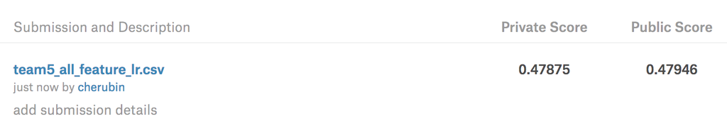

```python
Image(filename="3.png")
```

Finally, we use the trained random forest model on the test files and upload the csv to Kaggle for testing.

```python
rf.predict(features_df_test_array)
rf_result = pd.DataFrame(data=rf.predict(features_df_test_array), columns=['relevance'])
rf_result['id'] = test_df['id']
```

```python
check_range_rf = rf_result['relevance'].tolist()
new_list_rf = []
for each_element in check_range_rf:
    if each_element < 1:
        new_list_rf.append(1)
    if each_element > 3:
        new_list_rf.append(3)
    if each_element > 1 and each_element <3:
        new_list_rf.append(each_element)
```

```python
rf_result['relevance'] = new_list_rf
```

```python
rf_result.to_csv('team5_all_feature_rf.csv', index = False)
```

The random forest model on iteration 2 is also significantly improved, as we found the RMSE on Kaggle drop from 0.4902 to 0.47440. The results are also better than the RMSE using linear regression, this shows random forest modeling helps to improve our prediction accuracy.

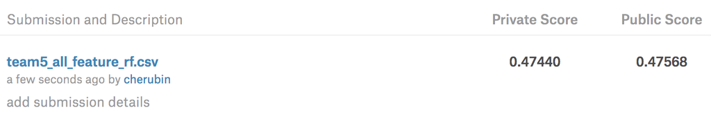

```python
Image(filename="4.png")
```

# Conclusion

The pipeline for our task starts from the basic iteration of using the common count and fuzzy score between search terms and product title & description as features. We then improve our accuracy by adding the word2vec cosine similarity features in the second iteration.

This task has provided us with some useful insights. From machine learning and data science point of view, our iteration process has proven the effectiveness of word2vec models and random forest model. The word2vec model takes into account the actual meaning of words and the fact that some words are inherently more related than others. The random forest model performs better since it has many trees to choose the most accurate results and can prevent overfitting.

# Future Work

Our task also provides foundations for future work to further increase prediction accuracy. Firstly, future work can introduce grid search when tuning the parameters. In our current work, we have tried manually tune some of the parameters, a structured grid search will help to find the optimal parameters and further decrease the RMSE. In addition, spell checks can be considered when processing the words. Spelling mistakes are common in search terms and it may help to reduce RMSE if effective spell checks are introduced. Last but not least, incorporating large neural networks into our model is other option. Now we have only implemented a plain-vanilla skip-gram word2vec model, larger neural networks may further decrease RMSE and improve prediction accuracy.